# Introduction

Ce projet explore divers aspects de la manipulation de données à l'aide de Python, en se concentrant sur les opérations de conversion, de dénormalisation, et de jointure de données. Mon projet débute par la transformation de données structurées en format CSV vers le format JSON, qui est plus flexible. Par la suite, le projet s'aventure dans la dénormalisation des données. Enfin, le projet utilise les bases de données Redis et MongoDB pour stocker et gérer ces données mais pourquoi utilise t'on mongodb et redis ?.

**MongoDB**, en tant que base de données orientée documents, brille par sa capacité à stocker des données flexibles et riches. Mongodb utilise des fichiers json qui permettent une représentation structurée des données, qui sera beaucoup plus adaptée à notre approche de dénormalisation. Ces documents peuvent contenir des informations variées . Ainsi, MongoDB s'affirme comme très bonne solution pour le stockage de données complexes.

D'un autre côté, **Redis**, en tant que base de données en mémoire à clé-valeur, excelle dans la rapidité d'accès aux données. Grâce à sa structure simple, Redis offre des performances très rapide pour les opérations de lecture et d'écriture. Dans notre projet, nous verrons comment Redis est un spécialiste dans la rapidité de traitement des données .

# Base de Données Utilisée pour le Projet

Dans le cadre de mon projet, j'ai utilisé une base de données relationnelle comprenant plusieurs tables interconnectées. Voici un aperçu des tables et de leurs structures :

## Tables de la Base de Données

### Table `AVIONS`

- **NumAv** : Numéro de l'avion.
- **NomAv** : Nom de l'avion.
- **CapAv** : Capacité de l'avion.
- **VilleAv** : Ville de l'avion.

### Table `PILOTES`

- **NumPil** : Numéro du pilote.
- **NomPil** : Nom du pilote.
- **NaisPil** : Date de naissance du pilote.
- **VillePil** : Ville du pilote.

### Table `CLIENTS`

- **NumCl** : Numéro du client.
- **NomCl** : Nom du client.
- **NumRueCl** : Numéro de rue du client.
- **NomRueCl** : Nom de rue du client.
- **CodePosteCl** : Code postal du client.
- **VilleCl** : Ville du client.

### Table `VOLS`

- **NumVol** : Numéro du vol.
- **VilleD** : Ville de départ.
- **VilleA** : Ville d'arrivée.
- **DateD** : Date de départ.
- **HD** : Heure de départ.
- **DateA** : Date d'arrivée.
- **HA** : Heure d'arrivée.
- **NumPil** : Numéro du pilote.
- **NumAv** : Numéro de l'avion.

### Table `DEFCLASSES`

- **NumVol** : Numéro du vol.
- **Classe** : Classe de vol.
- **CoeffPrix** : Coefficient de prix.

### Table `RESERVATIONS`

- **NumCl** : Numéro du client.
- **NumVol** : Numéro du vol.
- **Classe** : Classe de réservation.
- **NbPlaces** : Nombre de places réservées.

## Utilisation dans le Projet

# PARTIE 1 : Travail sur le format JSON

## Conversion CSV en JSON

### Objectif et Importance

Cette section du projet se concentre sur la conversion de données du format CSV au format JSON . Cette étape est cruciale pour plusieurs raisons :

#### Facilité de Manipulation

Le format JSON est largement utilisé pour sa facilité de manipulation, en particulier dans les langages de programmation comme Python. Les structures de données en JSON sont flexibles.

#### Interopérabilité et Stockage

Le JSON est également un format standard pour l'échange de données sur le web, Par exemple, lors de l'utilisation d'API pour interagir avec les données, les requêtes génèrent des résultats formatés en JSON. De plus, il est plus adapté au stockage dans des systèmes de bases de données NoSQL tels que MongoDB.

#### Script csv_to_json

Ce script utilise la bibliothèque pandas pour convertir un fichier CSV en fichier JSON. Il lit le fichier CSV spécifié, traite les colonnes pour les dates si nécessaire, et sauvegarde les données dans un fichier JSON avec une orientation des enregistrements, ce qui signifie que chaque ligne du CSV deviendra un objet JSON distinct dans un tableau JSON.

```python
import pandas as pd

def convert_csv_to_json(input_csv_path, output_json_path, target_columns, date_columns=None):
    # Charger les données depuis le fichier CSV en utilisant une tabulation comme délimiteur
    data_frame = pd.read_csv(input_csv_path, delimiter='\t', header=None, names=["RawData"])

    # Diviser la colonne "RawData" en plusieurs colonnes en utilisant la tabulation comme séparateur
    parsed_data = data_frame["RawData"].str.split('\t', expand=True)

    # Renommer les colonnes avec les noms spécifiés
    parsed_data.columns = target_columns

    # Si des colonnes de date sont spécifiées, convertir les valeurs en format de date spécifié
    if date_columns:
        for date_col in date_columns:
            parsed_data[date_col] = pd.to_datetime(parsed_data[date_col], format='%d/%m/%y').dt.strftime('%d/%m/%y')

    # Exporter les données au format JSON avec une indentation de 2 espaces
    parsed_data.to_json(output_json_path, orient='records', indent=2)

# Exemple d'utilisation avec des noms de variables différents
convert_csv_to_json(
    "C:\\Users\\ilyes\\Desktop\\Bddcsv\\Clients.csv",
    "C:\\Users\\ilyes\\Desktop\\Bddcsv\\Clients.json",
    ["NumCl","NomCl","NumRueCl","NomRueCl","CodePosteCl","VilleCl"] ##LIGNE A MODIFIER SELON LES ATTRIBUTS DES TABLES

)

json_path = "C:\\Users\\ilyes\\Desktop\\Bddcsv\\Clients.json"
df_result = pd.read_json(json_path)

# Afficher quelques lignes du DataFrame
print(df_result.head())
```

```
   NumCl      NomCl  NumRueCl          NomRueCl  CodePosteCl     VilleCl
0   1001  Becquerel        24      Rue De Fabre        13015   Marseille
1   1002    Leblanc         1       Rue De Rome        87031     Limoges
2   1003   Lippmann        10         Place Pie        44076      Nantes
3   1004  Debroglie        50     Rue De Monaco        34000    Toulouse
4   1005    Moissan         5  Place Castellane        67000  Strasbourg
```

## Denormalisation des données

### Jointure des Données JSON

#### Objectif de la Jointure

Cette partie du projet implique la jointure de deux ensembles de données JSON, `Avions.json` et `Vols.json`, sur un attribut commun. Le script implémente une Jointure Interne (Inner Join) entre les ensembles de données Avions.json et Vols.json. Seuls les enregistrements ayant une correspondance exacte sur l'attribut NumAv dans les deux fichiers sont retenus.

#### Processus de Jointure

Chaque paire d'entrées des deux fichiers est comparée. Si les valeurs de l'attribut spécifié (`NumAv` dans ce cas) correspondent, les informations des deux entrées sont combinées en un seul objet.

#### Avantages de cette Approche

- **Données Consolidées :** Permet de consolidées les donneés , ce qui permets de trouver les données a un endroit consolidées.
- **Flexibilité et Réutilisation :** La fonction de jointure peut être appliquée à différents ensembles de données et attributs, et sera réutilisée pour intégrer les données dans MongoDB.

# PARTIE 2 : Redis

Redis est une base de données en mémoire open-source de type NoSQL. Elle est conçue pour stocker et gérer des données en utilisant une structure de données clé-valeur.

### Utilisations Courantes de Redis

- **Caching :** Redis est souvent utilisé pour mettre en cache des données fréquemment consultées afin d'accélérer l'accès aux informations.
- **Systèmes de Messagerie :** Il peut servir de système de messagerie interne entre les différentes parties d'une application.

### Configuration Expérimentale

- **Ordinateur Portable :** Je travaille sur un ordinateur portable équipé d'un processeur Intel Core i3-1215U et de 8 Go de RAM pour les conditions expérimentales.

## Installation de Redis et RedisBloom

Pour ce projet, RedisBloom, une extension de Redis pour les structures de données probabilistes, a également été installé. Vous avez la possibilité de lancer Redis et RedisBloom en utilisant une image Docker ou en configurant une machine virtuelle en suivant les instructions du dépôt GitHub de RedisBloom. L'installation via Docker est plus simple, tandis que la configuration d'une machine virtuelle offre davantage de flexibilité mais est plus complexe à mettre en place, notamment pour l'installation de RedisBloom.

## Objectif du Test d'Efficacité de RedisBloom

Ce test vise à évaluer l'efficacité de RedisBloom, une extension de Redis, dans la détection de doublons au sein d'un ensemble de données CSV. Le fichier "DEMO.csv" peut être récupéré via la commande `curl http://rali.iro.umontreal.ca/DEM//DEM-1_1.csv > DEMO.csv`. Il est utilisé comme jeu de données dans l'ensemble Redis "my_set".

## Objectif de l'Expérimentation

L'objectif de cette expérimentation est de mesurer les performances de RedisBloom dans la détection de doublons au sein du fichier CSV "DEMO.csv". Le test évalue l'efficacité de cette opération par rapport à une recherche classique, en particulier pour gérer de grandes quantités de données. Cette expérimentation permet de déterminer si RedisBloom est une solution efficace pour cette tâche spécifique.

### Évaluation de l'efficacité du script avec différentes tailles de données

```python
import csv
from json import dumps
import redis
import time

def perf_set(csv_file, n):

    r = redis.Redis()

    r.delete("my_set")

    with open(csv_file, encoding = 'utf-8') as csvfile:
        my_reader = csv.DictReader(csvfile,delimiter='\t')
        my_data = [my_row for my_row in my_reader]
        #print(my_data)
        pres = dup = 0
        print('Start to create the set over',n,'inputs')
        # get the start time
        st = time.process_time()
        for my_row in my_data[0:n]:
            #print(my_row['M'])
            if not r.sismember("my_set", my_row['M']):
                r.sadd("my_set", my_row['M'])
                pres = pres + 1
            else:
                dup = dup + 1
        # get the end time
        et = time.process_time()
        # get execution time
        res = et - st
        print('CPU Execution time:', res, 'seconds')
        print('We found',dup,'duplicates in the input')
        print()
        print('Wall time (also known as clock time or wall-clock time) is simply the total time')
        print('elapsed during the measurement. Itâ€™s the time you can measure with a stopwatch.')
        print('It is the difference between the time at which a program finished its execution and')
        print('the time at which the program started. It also includes waiting time for resources.')
        print()
        print('CPU Time, on the other hand, refers to the time the CPU was busy processing')
        print('the programâ€™s instructions. The time spent waiting for other task to complete')
        print('(like I/O operations) is not included in the CPU time. It does not include')
        print('the waiting time for resources.')
#Step 1

n_values = [1000, 5000, 10000, 15000, 20000]
execution_times = []

for n in n_values:
    execution_time = perf_set("C:\\Users\\ilyes\\Desktop\\Bddcsv\\DEMO.csv", n)
    execution_times.append(execution_time)
```

```
Start to create the set over 1000 inputs
CPU Execution time: 0.125 seconds
We found 77 duplicates in the input

Wall time (also known as clock time or wall-clock time) is simply the total time
elapsed during the measurement. Itâ€™s the time you can measure with a stopwatch.
It is the difference between the time at which a program finished its execution and
the time at which the program started. It also includes waiting time for resources.

CPU Time, on the other hand, refers to the time the CPU was busy processing
the programâ€™s instructions. The time spent waiting for other task to complete
(like I/O operations) is not included in the CPU time. It does not include
the waiting time for resources.
Start to create the set over 5000 inputs
CPU Execution time: 0.6875 seconds
We found 545 duplicates in the input

Wall time (also known as clock time or wall-clock time) is simply the total time
elapsed during the measurement. Itâ€™s the time you can measure with a stopwatch.
It is the difference between the time at which a program finished its execution and
the time at which the program started. It also includes waiting time for resources.

CPU Time, on the other hand, refers to the time the CPU was busy processing
the programâ€™s instructions. The time spent waiting for other task to complete
(like I/O operations) is not included in the CPU time. It does not include
the waiting time for resources.
Start to create the set over 10000 inputs
CPU Execution time: 0.734375 seconds
We found 1062 duplicates in the input

Wall time (also known as clock time or wall-clock time) is simply the total time
elapsed during the measurement. Itâ€™s the time you can measure with a stopwatch.
It is the difference between the time at which a program finished its execution and
the time at which the program started. It also includes waiting time for resources.

CPU Time, on the other hand, refers to the time the CPU was busy processing
the programâ€™s instructions. The time spent waiting for other task to complete
(like I/O operations) is not included in the CPU time. It does not include
the waiting time for resources.
Start to create the set over 15000 inputs
```

[output cut: 10 more lines]

```
(like I/O operations) is not included in the CPU time. It does not include
the waiting time for resources.
Start to create the set over 20000 inputs
CPU Execution time: 1.5625 seconds
We found 2425 duplicates in the input

Wall time (also known as clock time or wall-clock time) is simply the total time
elapsed during the measurement. Itâ€™s the time you can measure with a stopwatch.
It is the difference between the time at which a program finished its execution and
the time at which the program started. It also includes waiting time for resources.

CPU Time, on the other hand, refers to the time the CPU was busy processing
the programâ€™s instructions. The time spent waiting for other task to complete
(like I/O operations) is not included in the CPU time. It does not include
the waiting time for resources.
```

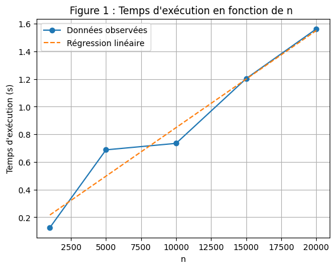

```python
import matplotlib.pyplot as plt
import numpy as np

# Valeurs de n
n_values = [1000, 5000, 10000, 15000, 20000]

# Temps d'exécution correspondants
execution_times = [0.125, 0.6875, 0.734375, 1.203125, 1.5625]

# Régression linéaire
coefficients = np.polyfit(n_values, execution_times, 1)
a, b = coefficients

# Création du graphique
plt.plot(n_values, execution_times, marker='o', label='Données observées')
plt.plot(n_values, a * np.array(n_values) + b, '--', label=f'Régression linéaire')
plt.xlabel('n')
plt.ylabel('Temps d\'exécution (s)')
plt.title('Figure 1 : Temps d\'exécution en fonction de n ')
plt.legend()
plt.grid(True)
plt.show()
```